# Experimental Sociology - Week 11

Calibration

Published

2025-03-21

This week, we will extend our agent-based model (ABM) of opinion dynamics by introducing **calibration**, a crucial procedure for aligning our simulations with real-world observations. Calibration involves systematically adjusting the parameters of a model until the simulated outcomes closely match observed data. This process increases the realism and reliability of our simulations, making our models more useful for understanding real-world phenomena and is a necessary step if we want to run experiments *in silico*.

**Note**

The code for this week: https://github.com/SGrehl/SGrehl.github.io/tree/main/data/abm-opinion1:

# Learning Goals

1. Understand the purpose and workflow of model calibration.
2. Recognize the desirable properties of a fit function.
3. Define and implement a fit function using R.
4. Calibrate an ABM using data.

# 🔍 Realism

Before exploring the technical details of calibration, it is essential to understand **why** calibration matters. The primary purpose of calibration is **realism**: ensuring our ABM reflects reality as closely as possible.

When our goal is to capture certain aspects of real-world phenomena, our model should closely align with observable facts or data. We broadly refer to this alignment as realism.

There are three main forms of realism in ABMs:

- **Input Realism**: Ensuring the parameters fed into our model accurately represent the observed world. Parameters can be:
  - **Observable parameters** (e.g., network structures, demographics).
  - **Non-observable parameters** (e.g., individual tendencies, internal motivations).
- **Model Realism**: Ensuring the mechanisms, rules, or processes within our model accurately reflect plausible real-world processes.
- **Output Realism**: Ensuring the outcomes or patterns produced by our model match empirical observations or data.

Of these, observable input realism is the easiest to handle because we can directly incorporate known empirical data. For instance, if we know the social network in a community, we directly use that network within our ABM. Non-observable parameters, however, are more challenging since we cannot measure them directly. The same is true for structural realism of the model mechanisms themselves.

Therefore, the only way to reliably validate non-observable parameters and model mechanisms is to examine their outputs. If the simulated outcomes deviate significantly from observed reality, we adjust the non-observable parameters and possibly even the model structure until we achieve a good fit between simulated results and observed data.

This systematic adjustment process is called **calibration**.

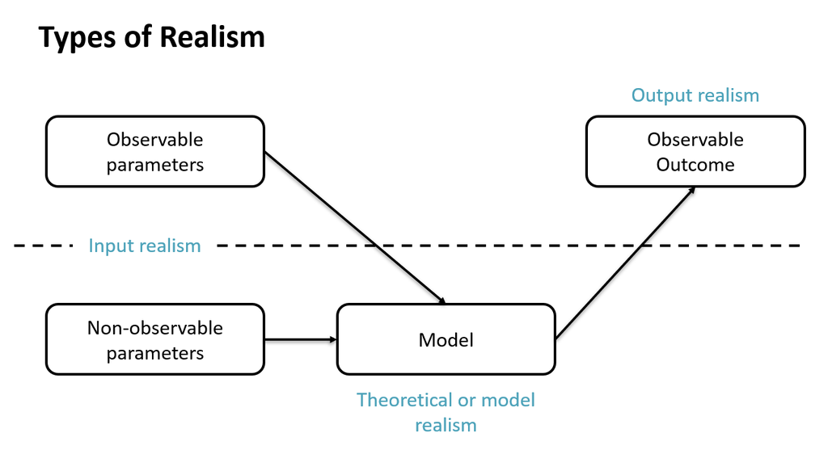

Figure 1: Types of realism in ABM.

It’s important to remember that models, like scientific hypotheses, can only ever be proven incorrect; they cannot be definitively proven correct. If our model generates results drastically different from reality, it strongly suggests something in our model is incorrect. However, even if our model produces results that closely match observed data, it does not necessarily confirm that the underlying mechanisms or parameters of our model accurately reflect reality.

Indeed, it is possible to have a model that appears realistic in terms of outputs, but whose underlying mechanisms are fundamentally flawed. Historically, a clear example of this issue was the Ptolemaic epicycle model, where the planets and Sun were assumed to orbit Earth. This model matched observational data very well for centuries, despite being fundamentally incorrect. Figure Figure 2 illustrates how Venus’s movements were represented in this causal incorrect but seemingly accurate model.

[figure not shown]

Figure 2: The geocentric epicycle model, demonstrating how Venus was incorrectly assumed to orbit Earth.

## Observable parameters

To ensure input realism, we first integrate observable parameters directly from empirical data into our models. Observable parameters are those which we can measure directly from the real world.

For instance, Zachary’s (1977) classic karate club data set provides observable social network structures. We know precisely who is connected to whom, and we also have the observed outcome—how the club eventually split into two factions. Such observable parameters can be directly incorporated into our ABM.

Here’s how we can visualize Zachary’s karate faction data in R:

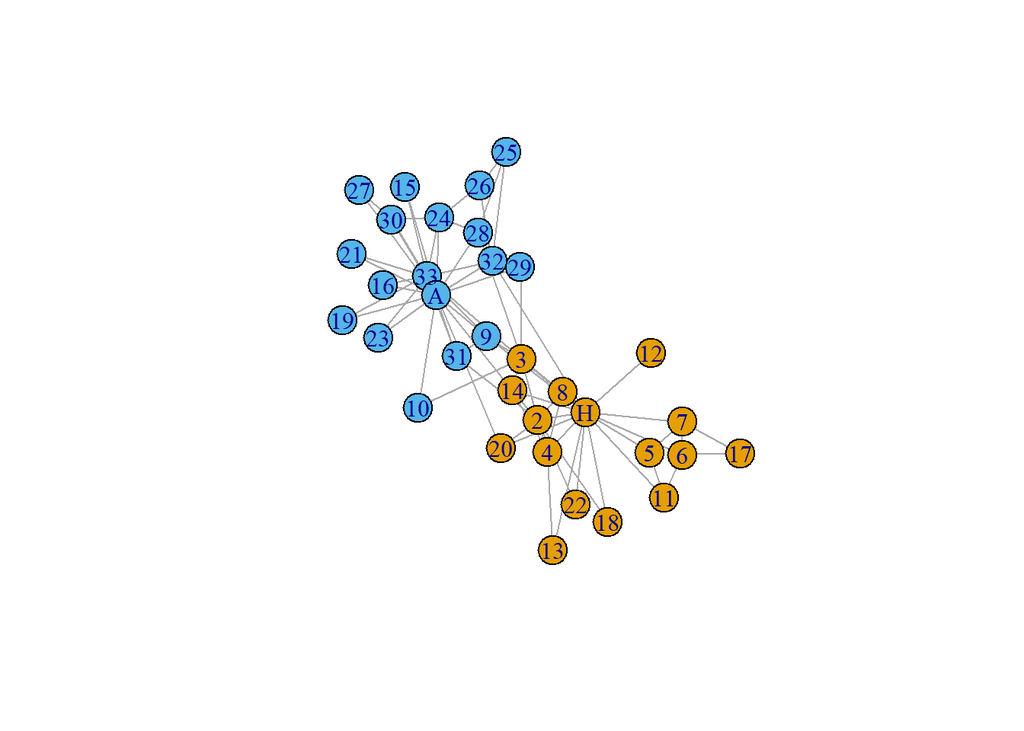

Figure 3: The famouse karate club split data set.

```r
data(karate)
plot(karate)
```

Besides network structures, we can use other kinds of observable parameters such as geographical information systems (GIS) data, demographic statistics, or mobility data. For example, Hägerstrand (1965) famously utilized telephone-call data in Sweden to estimate interaction frequencies between individuals in different geographical regions. Such real-world datasets helped Hägerstrand calibrate his ABM to achieve much higher realism than could have been obtained through mere guesswork.

However, even observable parameters have limitations. For example, Zachary’s karate faction network is represented as a binary friendship/no-friendship relationship. Real friendships, however, often vary in strength and frequency of interaction. Similarly, Hägerstrand’s data was constrained by the technological and methodological limitations of his time. In Figure 4 is what GIS data of a Swedish province looked like in the 60s. Today, we might have access to more precise communication logs or GPS-based movement tracking, enhancing input realism significantly.

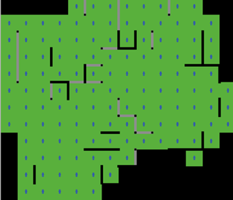

Figure 4: A model of a Swedish province. The GIS data (mountains and rivers) is then used to better model the diffusion process of an innovation (Hägerstrand 1965).

Thus, realism in ABM is always context-dependent and shaped by practical constraints such as available data and technology.

We will now turn to the detailed steps involved in the calibration process, including how to define an appropriate fit function and how to systematically explore parameter spaces to identify optimal parameter settings.

# 🎯 Calibrating

Having addressed observable parameters and input realism, let us now turn our attention to the **unobservable aspects** of our model. Unlike observable parameters, these non-observable elements cannot be measured directly, not even approximately. Therefore, to calibrate them, we must rely entirely on systematic trial-and-error or informed guesswork guided by a structured approach.

## Defining What to Fit

The first step in calibration is deciding clearly **what** aspects of the model’s outcomes you want to fit to empirical data. For instance, consider Zachary’s karate faction example again:

- Do we primarily care about the **final state** (e.g., who ends up in which faction)?
- Or are we interested in the **process itself** (how quickly factions emerge, how rapidly opinions spread)?
- Or perhaps we want to consider **both**, assigning weights to balance their relative importance?

Whatever our calibration objective, it is crucial to explicitly define it and prepare our data accordingly. Consider the karate faction example again: we might aim to replicate each individual’s specific decision—whether they stayed loyal to Mr. Hi or joined Officer John’s new faction. In that case, our calibration targets precise outcomes for each faction member:

```r
tbl <- rbind(
  member = seq_along(V(karate)$Faction),
  faction   = as.integer(V(karate)$Faction)
)

# Display as a nice table
knitr::kable(tbl, caption = "Faction Membership in Karate Graph (1=Mr. Hi, 2=John A.)")
```

Faction Membership in Karate Graph (1=Mr. Hi, 2=John A.)

| member | 1 | 2 | 3 | 4 | 5 | 6 | 7 | 8 | 9 | 10 | 11 | 12 | 13 | 14 | 15 | 16 | 17 | 18 | 19 | 20 | 21 | 22 | 23 | 24 | 25 | 26 | 27 | 28 | 29 | … |
| --- | --- | --- | --- | --- | --- | --- | --- | --- | --- | --- | --- | --- | --- | --- | --- | --- | --- | --- | --- | --- | --- | --- | --- | --- | --- | --- | --- | --- | --- | --- |
| faction | 1 | 1 | 1 | 1 | 1 | 1 | 1 | 1 | 2 | 2 | 1 | 1 | 1 | 1 | 2 | 2 | 1 | 1 | 2 | 1 | 2 | 1 | 2 | 2 | 2 | 2 | 2 | 2 | 2 | … |

Alternatively, we might only care about replicating the aggregate numbers—how many members ended up in each faction—without focusing on individual-level outcomes:

```r
faction_counts <- table(V(karate)$Faction)  # gives named vector

# Build 2-row matrix
tbl <- rbind(
  faction = names(faction_counts),
  members = as.integer(faction_counts)
)

# Display as a nice table
knitr::kable(tbl, caption = "Number of Faction Members in Karate Graph (1=Mr. Hi, 2=John A.).")
```

Number of Faction Members in Karate Graph (1=Mr. Hi, 2=John A.).

| faction | 1 | 2 |
| --- | --- | --- |
| members | 16 | 18 |

While accurately replicating individual-level outcomes is generally preferable—since it represents a closer match to reality—this is not always possible or practical. Agent-based models often incorporate random processes or are sensitive to initial conditions and path dependencies, making precise replication of every detail difficult or unrealistic. Therefore, we often accept models that reliably replicate broader patterns, distributions, or general trends, rather than exact outcomes for every individual or event.[^1]

### Preparing Data for Calibration

Effective calibration requires preparing structured empirical data as well as generating synthetic data from your simulation in the same format. The synthetic data must closely mirror the empirical data you aim to replicate. For example, if you are calibrating your model to match a time-series observation, your model should produce outputs that match the structure of this empirical data.

Consider, for instance, modeling faction affiliation starting from an initial neutral opinion state (0.5, indicating membership in a single unified faction). Eventually, individuals adopt either Mr. Hi’s faction (coded as 1) or Officer John’s faction (coded as 2). In this scenario, a function that transforms simulation outcomes into the same format as the observed data (`V(karate)$color`) could look like this:

```r
as.comparable_df <- function(
    sim = NULL,
    emp = NULL
) {
  if (is.null(sim) & is.null(emp)) stop("This function needs either `sim` or `emp`")

  if (is.null(emp)) {
    opinions <- sim$df_final_world$opinions
  } else {
    opinions <- emp - 1 # convert 1 and 2 to 0 and 1
  }

  # Convert to 1 × N matrix
  opin_mat <- matrix(
    ifelse(opinions > 0.5, 1, 0),
    ncol = length(opinions)
  )

  # Convert to tibble with column names V1, V2, ...
  as_tibble(opin_mat, .name_repair = ~ paste0("V", seq_along(.)))
}
```

This function creates a data frame from either empirical or simulated data, ensuring both are in a comparable format for calibration. When applied to empirical data, it uses the `Faction` attribute from the karate network directly. For simulated data, it derives faction affiliation from each individual’s opinion: agents with opinion values above 0.5 are assigned to Officer John’s faction (coded as 1), while those with values of 0.5 or below are assigned to Mr. Hi’s faction (coded as 0).[^2] By standardizing the structure in this way, we can generate empirical and synthetic datasets that are directly comparable—an essential step for reliable calibration.

Such consistent formatting ensures a direct and meaningful comparison between simulation outputs and empirical observations, facilitating a reliable calibration process.

## Properties of a Good Fit Function

Once data is prepared, calibration relies on defining a suitable **fit function**, also known as an objective function, error metric, or distance measure. The fit function quantifies how closely the simulation’s outputs match observed empirical data.

A commonly used fit function that satisfies these properties is:

$$Fit = \sum_{i=1}^v w_i \cdot \left( \frac{emp_i−syn_i}{\frac{emp_i+syn_i}{2}} \right) ^2$$

With

- $emp_i$ = Empirical (observed) value $i$.
- $syn_i$ = Synthetic (simulated) value $i$.
- $w_i$ = Weight assigned to this particular data point $i$.
- $v$ = Number of data points fitted.

This function computes the squared relative difference, ensuring symmetry, non-negativity, and dimensionlessness. The weight $w_i$ allows for the prioritization of specific data points. However, to achieve this, the minimum values of $emp_i$ and $syn_i$ must be set to 0, which may require some data transformation. Then an perfect fits is always a Fit of 0.

### Defining the Fit Function

To quantitatively assess the similarity between our simulation output and historic data, we define the `get_measure_fit_simple()` function.[^3] This function calculates the fit score by comparing the relevant metrics extracted from both datasets.

```r
# Example measure of fit between two reports
get_measure_fit_simple <- function(empirical_data,
                                   synthetic_data
                                  ) {
  diffs <- numeric(length(compare_cols_emp))

  for (i in seq_along(empirical_data)) {
    v_emp <- as.numeric(empirical_data[i])
    v_syn <- as.numeric(synthetic_data[i])

    #Compute relative squared differences
    rel_sq_diff <- ((v_emp - v_syn) / (v_emp + v_syn) / 2 )^2

    # Handle divide by 0 cases
    diffs[i] <- ifelse(is.nan(rel_sq_diff), 0, rel_sq_diff)
  }

  # Step 2: Return average fit score
  mean(diffs, na.rm = TRUE)
}
```

## Running the Calibration

Now that we have clearly defined our fit function, it’s time to perform a full calibration. We start by specifying our simulation, similar to previous weeks:

```r
simulation  <- list(
  model = "karate",
  replications = 1,
  tbl_parameter = expand.grid(
    influence_epsilon = seq(0.40, 1, by=.2)
  ),
  master_seed  = 42
)
```

The `karate` model uses Zachary’s empirical karate network. To accomplish this, we modified our `init_world()` function to incorporate the empirical karate faction network observed by Zachary (1977). Additionally, we set initial opinion values explicitly: Mr. Hi (faction leader 1) receives an opinion value of `0`, Officer John A. (faction leader 34) receives an opinion value of `1`, and all other members start with a neutral value of `0.5`. Here’s how the initialization function was adjusted:

```r
init_world <- function(model) {
 #...
  if (model$network == "karate") { # get the empirical karate network
    library(igraphdata)
    data(karate)
    agents <- karate
  }

  #...

  # Set all opinions to 0.5, but for Mr. Hi and John A.
  if (model$network == "karate") {
    V(agents)$opinions <- rep(list(0.5), 34)
    V(agents)[[1]]$opinions  <- 0 # Mr. Hi
    V(agents)[[34]]$opinions <- 1 # John A.

  }

  #...
}
```

With these adjustments, the two potential sources of randomness in our simulation—network generation and initial opinions—are now eliminated. This makes our simulation **fully deterministic**, and thus no additional replications are required.

For modeling opinion dynamics, it makes conceptual sense to apply a positive influence model (“bounded confidence”), as both leaders actively attempt to persuade members to align with their respective faction. We will explore varying values of the `influence_epsilon` parameter during calibration.

However, before running the calibration, we also need to make a critical adjustment to our `run_step()` function. Since we explicitly assume the faction leaders’ opinions are fixed and unwavering, we ensure that Mr. Hi and Officer John A. do not change their opinions throughout the simulation:

```r
run_step <- function(world, model) {

  # ...

  # this is the loop for updating each agent i's opinon
  for (i in seq_along(V(agents))) {

    # in the karate network, Mr. Hi and John A. do not change their opinion
    if (model$network == "karate") {
      if (i ==  1) { # Mr. Hi
        new_opinions[1] <- old_opinions[1]
        next
      }
      if (i == 34) { # John A.
        new_opinions[34] <- old_opinions[34]
        next
      }
    }
    # ...
  }
  # ...
}
```

To systematically evaluate our model against empirical data, we expand the `run_simulation()` function to accept empirical data as an additional parameter. This modified function calculates and returns a new data frame (`df_calibration`) that contains the parameter values used in each run along with their corresponding fit scores.

Here’s how this modified `run_simulation()` function looks:

```r
run_simulation <- function(simulation,
                           empirical_data = NULL){
  # ...

    if (!is.null(empirical_data)) {
      # pick whichever summary you compare (e.g. time-series)
      syn_df <- as.comparable_df(sim = result)
      emp_df <- as.comparable_df(emp = empirical_data)
      fit    <- get_measure_fit(empirical_data  = emp_df,
                                synthetic_data = syn_df)
      # store the single-row tibble of params + fit
      results_calibration[[i]] <- tibble(fit = fit,
                                         !!!tmp_parameter
                                         )
    }
  # ...
  out$df_calibration <- bind_rows(results_calibration)

  return(out)
}
```

Now, with everything properly set up, we can run a full calibration simulation using our karate faction empirical data:

```r
  data(karate)
  results <- run_simulation(simulation,
                            empirical_data = V(karate)$Faction)
```

After executing this simulation, we examine the calibration results directly:

```r
  results$df_calibration
```

```
# A tibble: 4 × 2
    fit influence_epsilon
  <dbl>             <dbl>
1 2                   0.4
2 0.118               0.6
3 0                   0.8
4 0                   1
```

From the resulting table, we can interpret the calibration outcomes. For instance, with an epsilon value of $\epsilon = 0.4$, the fit score might be relatively high (indicating a poorer fit), as agents with neutral initial opinions (0.5) are not sufficiently influenced by the extreme opinions held by Mr. Hi and Officer John A. On the other hand, when $\epsilon$ values are greater than approximately 0.8, we observe a perfect fit (fit = 0), meaning our model perfectly replicates the empirical data under these parameter settings.

# 🧩 Conclusion

In this chapter, we explored the essential process of **calibration** in agent-based modeling—a key step toward increasing the realism and credibility of simulation results. By defining clear calibration targets, preparing matching empirical and synthetic data structures, and applying robust fit functions, we gained the ability to quantitatively assess how well a model reproduces observed patterns.

The example we used in this chapter was deliberately simple: a **deterministic model** with only **one free parameter**. This allowed us to focus on the logic and mechanics of calibration without being overwhelmed by complexity. However, in real scientific applications, calibration is often much more challenging. Models typically include multiple uncertain parameters, interact in non-obvious ways, and exhibit **stochastic behavior**, meaning repeated runs may yield different outcomes even with the same settings.

To reflect this added complexity, in the **in-class session**, we will move beyond the simplified example and explore **calibrating two parameters** in a **non-deterministic scenario**. This will allow you to see how calibration strategies adapt to real-world challenges, including randomness, trade-offs, and multi-dimensional parameter spaces.

Understanding these complexities is crucial if you want to use ABMs as scientific tools rather than illustrative demonstrations. Calibration is not just about fine-tuning a model—it’s about building a bridge between theory and evidence.

# 🚀 Link to In-Class Material

Here is the link for the in-class material.

## References

Hägerstrand, Torsten. 1965. “A Monte Carlo Approach to Diffusion.” *European Journal of Sociology* 6 (1): 43–67. https://doi.org/10.1017/S0003975600001132.

Keuschnigg, Marc. 2015. “Product Success in Cultural Markets: The Mediating Role of Familiarity, Peers, and Experts.” *Poetics* 51 (August): 17–36. https://doi.org/10.1016/j.poetic.2015.03.003.

Zachary, Wayne W. 1977. “An Information Flow Model for Conflict and Fission in Small Groups.” *Journal of Anthropological Research* 33 (4): 452–73. https://doi.org/10.1086/jar.33.4.3629752.

## Footnotes

[^1]: For example, no model can reliably predict exactly *which* specific book will become a bestseller. However, if our model accurately reproduces the general distribution of successful versus unsuccessful books, we typically consider that sufficient for practical purposes (Keuschnigg 2015) . Thus, we often accept models that reliably replicate broader patterns, distributions, or general trends rather than exact outcomes for every individual or event.
[^2]: Notice that we transformed the faction identifiers from 1 and 2 to 0 and 1. We performed this transformation to ensure the minimal achievable fit value is zero, which simplifies interpretation and facilitates the calibration process. The next section explains in more detail why such transformations are beneficial when defining fit functions.
[^3]: For more advanced calibration scenarios, this week’s accompanying code also provides the `get_measure_fit()` function, which offers additional flexibility, such as evaluating model fit over multiple time steps and assigning custom weights to different data points or dimensions. Such advanced functions enable a more nuanced and precise calibration process, especially when handling complex empirical patterns or time-dependent outcomes.

## Copyright

Copyright Sascha Grehl, 2025. All Rights Reserved